# LeveeFailure

Lohit Marla

2023-11-05

The dataset “leveefailure.csv” provides information about levee failures on the lower Mississippi River and potential predictor variables. The binary response variable “Failure” indicates whether a levee failure occurred (1 for “yes” and 0 for “no”). The predictor variables include Year of observation, RiverMile (location on the river), Sediments (presence or absence of coarse-grain channel fill), BorrowPit (presence or absence of material extraction pits), MeanderLocation (characteristics of the river’s meander at the levee location), ChannelWidth (width of the river channel), FloodwayWidth (width between levees or bluffs), Constriction Factor (floodway constriction over time), LandCoverType (characteristics of the land near the levee), VegetativeBufferWidth (width of plant life buffer near the levee), Sinuosity (river’s tendency to meander), DredgingIntensity (material dredging), and BankRevetement (structures on river banks).

We need to figure out the suitable predictors in the available basket of predictors

```r
failure.data <- read.csv("Data/leveefailure.csv")
str(failure.data)
```

```
## 'data.frame':    82 obs. of  15 variables:
##  $ Failure           : int  1 1 1 1 1 1 1 1 1 1 ...
##  $ Year              : int  1890 1890 1890 1890 1890 1910 1910 1910 1910 1910 ...
##  $ Rivermile         : num  847 787 776 776 773 830 785 785 785 784 ...
##  $ Sediments         : int  0 1 1 1 1 1 0 0 1 1 ...
##  $ Borrowpit         : int  0 0 0 0 0 0 0 0 0 0 ...
##  $ Meander           : int  4 3 3 3 2 1 1 1 1 1 ...
##  $ ChannelWidth      : num  1347 2581 3379 3507 1704 ...
##  $ Floodwaywidth     : num  2026 4123 7999 8538 4174 ...
##  $ ConstrictionFactor: num  1 1 1 1 1 ...
##  $ Landcover         : int  4 2 4 2 2 3 3 3 3 4 ...
##  $ VegWidth          : num  391 151 145 302 1028 ...
##  $ Sinuosity         : num  1.95 2.33 1.92 2.03 1.55 ...
##  $ Dredging          : int  0 0 0 0 0 81115 81115 81115 81115 81115 ...
##  $ Revetment         : int  0 0 0 0 0 0 0 0 0 0 ...
##  $ X                 : logi  NA NA NA NA NA NA ...
```

We have total of 82 observations with total of 15 variables whereas “Failure”, “Sediments”, “Borrowpit”, “Meander”, “Landcover” are the factor variables where as those where converted to factor variable in the following code

X column is having “N/A” in it so it was eliminated from the dataframe.

```r
failure.data$X <- NULL

variable_list <- c("Failure", "Sediments", "Borrowpit", "Meander", "Landcover")

for (var_name in variable_list) {
  if (var_name %in% names(failure.data)) {
    failure.data[[var_name]] <- as.factor(failure.data[[var_name]])
  } else {
    cat("Variable", var_name, "not found in the data frame.\n")
  }
}

str(failure.data)
```

```
## 'data.frame':    82 obs. of  14 variables:
##  $ Failure           : Factor w/ 2 levels "0","1": 2 2 2 2 2 2 2 2 2 2 ...
##  $ Year              : int  1890 1890 1890 1890 1890 1910 1910 1910 1910 1910 ...
##  $ Rivermile         : num  847 787 776 776 773 830 785 785 785 784 ...
##  $ Sediments         : Factor w/ 2 levels "0","1": 1 2 2 2 2 2 1 1 2 2 ...
##  $ Borrowpit         : Factor w/ 2 levels "0","1": 1 1 1 1 1 1 1 1 1 1 ...
##  $ Meander           : Factor w/ 4 levels "1","2","3","4": 4 3 3 3 2 1 1 1 1 1 ...
##  $ ChannelWidth      : num  1347 2581 3379 3507 1704 ...
##  $ Floodwaywidth     : num  2026 4123 7999 8538 4174 ...
##  $ ConstrictionFactor: num  1 1 1 1 1 ...
##  $ Landcover         : Factor w/ 4 levels "1","2","3","4": 4 2 4 2 2 3 3 3 3 4 ...
##  $ VegWidth          : num  391 151 145 302 1028 ...
##  $ Sinuosity         : num  1.95 2.33 1.92 2.03 1.55 ...
##  $ Dredging          : int  0 0 0 0 0 81115 81115 81115 81115 81115 ...
##  $ Revetment         : int  0 0 0 0 0 0 0 0 0 0 ...
```

Splitting the dataset based on the proportions of 78.1% as train dataset and 21.9 as test dataset.

```r
set.seed(123457)
train.prop <- 0.80
strats <- failure.data$Failure
rr <- split(1:length(strats), strats)
idx <- sort(as.numeric(unlist(sapply(rr,
        function(x) sample(x, length(x)*train.prop)))))
failure.data.train <- failure.data[idx, ]
failure.data.test <- failure.data[-idx, ]
```

```r
nrow(failure.data.train)/nrow(failure.data)
```

```
## [1] 0.7804878
```

```r
nrow(failure.data.test)/nrow(failure.data)
```

```
## [1] 0.2195122
```

Fitting the logit model on all the predictors

```r
full.logit <- glm(Failure ~ . ,data = failure.data.train,
                  family = binomial(link = "logit"))
summary(full.logit)
```

```
##
## Call:
## glm(formula = Failure ~ ., family = binomial(link = "logit"),
##     data = failure.data.train)
##
## Coefficients:
##                      Estimate Std. Error z value Pr(>|z|)
## (Intercept)        -2.247e+02  3.570e+03  -0.063   0.9498
## Year                1.334e-01  6.475e-02   2.060   0.0394 *
## Rivermile          -1.315e-02  1.155e-02  -1.139   0.2547
## Sediments1         -9.245e-01  1.047e+00  -0.883   0.3774
## Borrowpit1         -1.756e+00  1.702e+00  -1.032   0.3022
## Meander2           -2.482e+00  1.578e+00  -1.573   0.1158
## Meander3            1.880e+00  1.602e+00   1.173   0.2407
## Meander4           -1.086e+00  1.354e+00  -0.802   0.4227
## ChannelWidth        1.367e-03  8.100e-04   1.688   0.0915 .
## Floodwaywidth      -4.926e-04  3.400e-04  -1.449   0.1473
## ConstrictionFactor -1.564e+00  1.182e+00  -1.323   0.1858
## Landcover2         -1.875e+01  3.567e+03  -0.005   0.9958
## Landcover3         -2.036e+01  3.567e+03  -0.006   0.9954
## Landcover4         -1.823e+01  3.567e+03  -0.005   0.9959
## VegWidth            2.195e-05  4.509e-04   0.049   0.9612
## Sinuosity           1.676e+00  1.366e+00   1.226   0.2201
## Dredging           -5.963e-06  3.012e-06  -1.980   0.0477 *
## Revetment          -1.796e+01  3.300e+03  -0.005   0.9957
## ---
## Signif. codes:  0 '***' 0.001 '**' 0.01 '*' 0.05 '.' 0.1 ' ' 1
##
## (Dispersion parameter for binomial family taken to be 1)
##
##     Null deviance: 88.723  on 63  degrees of freedom
## Residual deviance: 45.187  on 46  degrees of freedom
## AIC: 81.187
##
## Number of Fisher Scoring iterations: 17
```

From the above summary we can interpret that Year, Dredging shows significant effect on the Failure variable

AIC: 81.187

Let’s interpret the model results

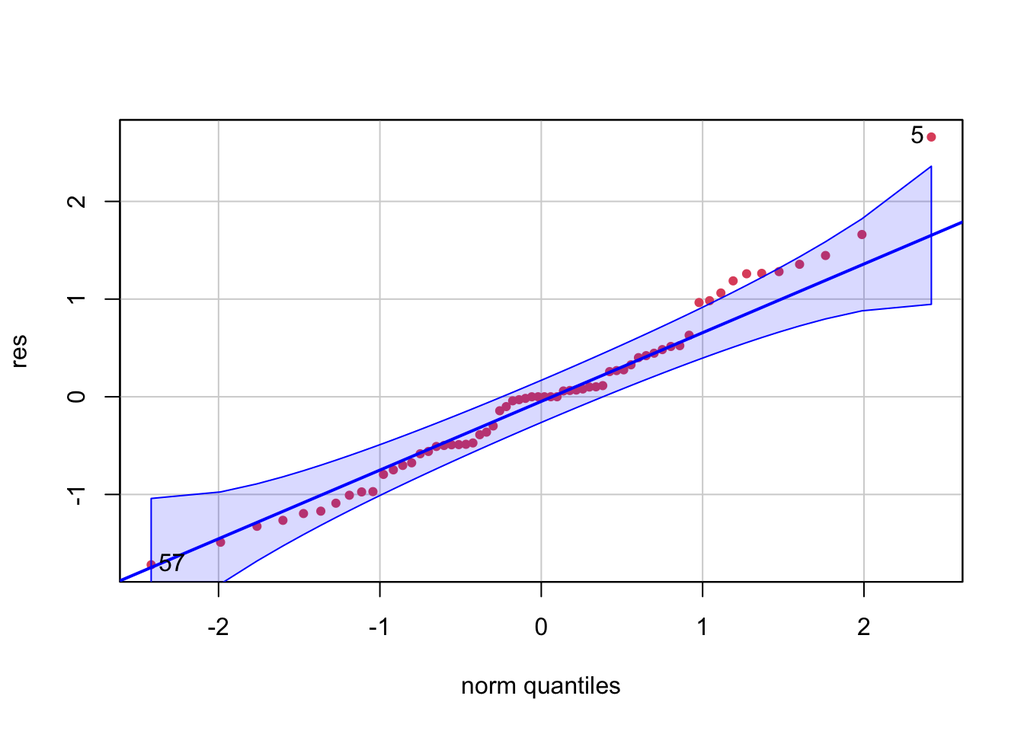

```
##  5 57
##  3 43
```

```r
res <-residuals(full.logit)
car::qqPlot(res, main = NA, pch = 19, col = 2, cex = 0.7)
```

There is some outliers from the above residual q-q plot. Let’s find out the outliers from the data and eliminate them from the train data

```r
extpts <- which(abs(residuals(full.logit)) > 3*sd(residuals(full.logit)))
extpts
```

```
## 5
## 3
```

After eliminating the outliers from the train data we fitted the logit model

```r
failure.data.outlier <- failure.data.train[-extpts,]
full.logit.outlier.glm <- glm(Failure ~ . ,data = failure.data.outlier,
                  family = binomial(link = "logit"))
summary(full.logit.outlier.glm)
```

```
##
## Call:
## glm(formula = Failure ~ ., family = binomial(link = "logit"),
##     data = failure.data.outlier)
##
## Coefficients:
##                      Estimate Std. Error z value Pr(>|z|)
## (Intercept)        -5.927e+02  3.195e+03  -0.185   0.8528
## Year                3.272e-01  1.333e-01   2.455   0.0141 *
## Rivermile          -2.097e-02  1.718e-02  -1.221   0.2222
## Sediments1         -2.680e+00  1.591e+00  -1.685   0.0921 .
## Borrowpit1         -3.138e+00  2.314e+00  -1.356   0.1749
## Meander2           -3.342e+00  1.964e+00  -1.701   0.0889 .
## Meander3            4.441e+00  2.615e+00   1.698   0.0894 .
## Meander4            3.295e-01  1.841e+00   0.179   0.8580
## ChannelWidth        2.785e-03  1.236e-03   2.253   0.0243 *
## Floodwaywidth      -5.578e-04  4.156e-04  -1.342   0.1795
## ConstrictionFactor -1.876e+00  1.506e+00  -1.246   0.2128
## Landcover2         -2.210e+01  3.185e+03  -0.007   0.9945
## Landcover3         -2.215e+01  3.185e+03  -0.007   0.9945
## Landcover4         -1.834e+01  3.185e+03  -0.006   0.9954
## VegWidth           -3.582e-04  5.703e-04  -0.628   0.5300
## Sinuosity           4.472e+00  2.574e+00   1.737   0.0823 .
## Dredging           -1.352e-05  5.820e-06  -2.322   0.0202 *
## Revetment          -1.885e+01  3.154e+03  -0.006   0.9952
## ---
## Signif. codes:  0 '***' 0.001 '**' 0.01 '*' 0.05 '.' 0.1 ' ' 1
##
## (Dispersion parameter for binomial family taken to be 1)
##
##     Null deviance: 87.321  on 62  degrees of freedom
## Residual deviance: 32.893  on 45  degrees of freedom
## AIC: 68.893
##
## Number of Fisher Scoring iterations: 17
```

From the above results we can observe AIC value is less when compared to the previous models also the difference between the null deviance and the residual deviance which is a good indication. However, residuals of the new model does not looks good. Which tells us that removing outliers form the dataset will cause further more complications to the data.

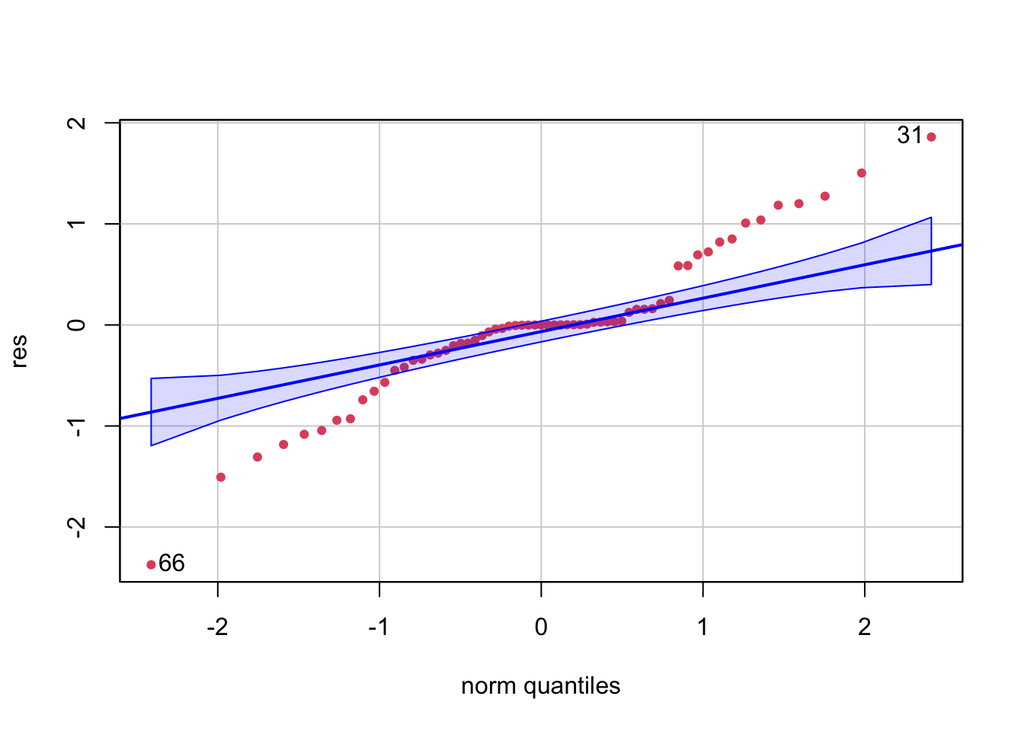

```
## 66 31
## 51 23
```

```r
res <- residuals(full.logit.outlier.glm)
car::qqPlot(res, main = NA, pch = 19, col = 2, cex = 0.7)
```

Let’s fit the logit model with the no predictors.

```r
null.logit <- glm(Failure ~ 1 ,data = failure.data.train,
                  family = binomial(link = "logit"))
summary(null.logit)
```

```
##
## Call:
## glm(formula = Failure ~ 1, family = binomial(link = "logit"),
##     data = failure.data.train)
##
## Coefficients:
##               Estimate Std. Error z value Pr(>|z|)
## (Intercept) -1.388e-17  2.500e-01       0        1
##
## (Dispersion parameter for binomial family taken to be 1)
##
##     Null deviance: 88.723  on 63  degrees of freedom
## Residual deviance: 88.723  on 63  degrees of freedom
## AIC: 90.723
##
## Number of Fisher Scoring iterations: 2
```

We can observe both the null and residual deviance are same where as the AIC value is 90.73 which is greater than the full model. Also the residual plot shows the over dispersed data.

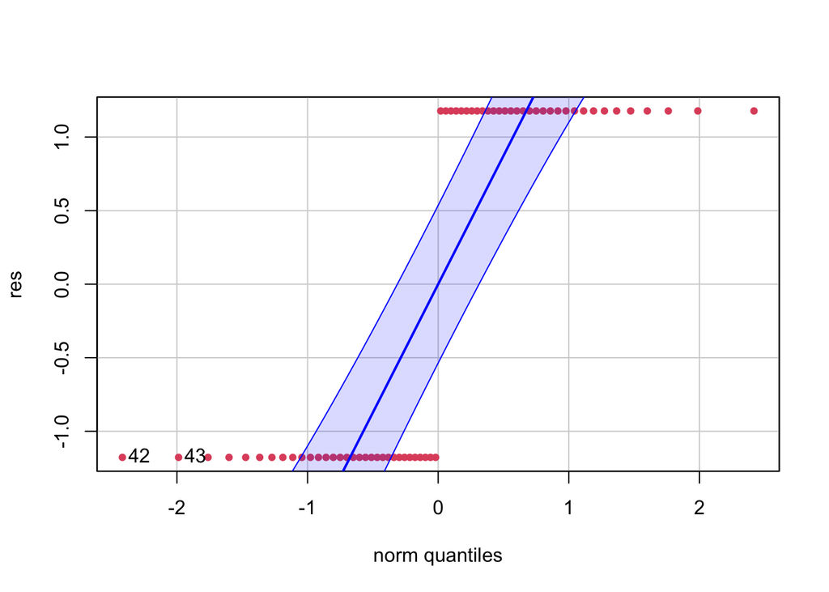

```
## 42 43
## 33 34
```

```r
res <- residuals(null.logit)
car::qqPlot(res, main = NA, pch = 19, col = 2, cex = 0.7)
```

Following code is to select the best significant variables from all the predictors available in the data with the help of the full and null model.

```r
both.logit <- step(full.logit, list(lower=formula(null.logit),
                                    upper=formula(full.logit)),
                   direction="both",trace=0, data = failure.data.train)
formula(both.logit)
```

```
## Failure ~ Year + Rivermile + Meander + Floodwaywidth + ConstrictionFactor +
##     Landcover + Sinuosity + Dredging
```

```r
summary(both.logit)
```

```
##
## Call:
## glm(formula = Failure ~ Year + Rivermile + Meander + Floodwaywidth +
##     ConstrictionFactor + Landcover + Sinuosity + Dredging, family = binomial(link = "logit"),
##     data = failure.data.train)
##
## Coefficients:
##                      Estimate Std. Error z value Pr(>|z|)
## (Intercept)        -1.792e+02  2.045e+03  -0.088   0.9302
## Year                1.112e-01  5.536e-02   2.009   0.0445 *
## Rivermile          -1.892e-02  8.723e-03  -2.169   0.0301 *
## Meander2           -2.710e+00  1.231e+00  -2.201   0.0277 *
## Meander3            1.477e+00  1.314e+00   1.124   0.2611
## Meander4           -3.924e-01  1.054e+00  -0.372   0.7096
## Floodwaywidth      -3.097e-04  2.092e-04  -1.480   0.1388
## ConstrictionFactor -1.620e+00  9.789e-01  -1.655   0.0979 .
## Landcover2         -1.701e+01  2.043e+03  -0.008   0.9934
## Landcover3         -1.943e+01  2.043e+03  -0.010   0.9924
## Landcover4         -1.766e+01  2.043e+03  -0.009   0.9931
## Sinuosity           2.577e+00  1.262e+00   2.043   0.0411 *
## Dredging           -6.496e-06  2.642e-06  -2.458   0.0140 *
## ---
## Signif. codes:  0 '***' 0.001 '**' 0.01 '*' 0.05 '.' 0.1 ' ' 1
##
## (Dispersion parameter for binomial family taken to be 1)
##
##     Null deviance: 88.723  on 63  degrees of freedom
## Residual deviance: 50.644  on 51  degrees of freedom
## AIC: 76.644
##
## Number of Fisher Scoring iterations: 16
```

AIC value is 76.644 which is less than both the full and null model also the difference between the null and residual deviance is good.

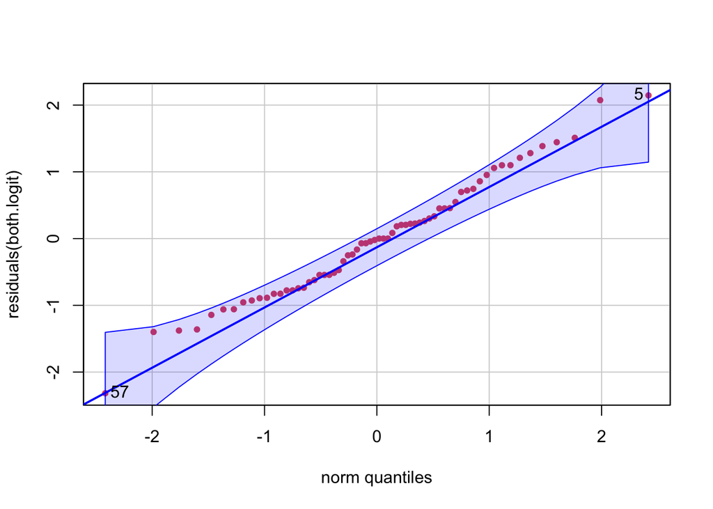

```
## 57  5
## 43  3
```

```r
res <- residuals(both.logit)
car::qqPlot(residuals(both.logit), main = NA, pch = 19, col = 2, cex = 0.7)
```

Out of all the three models we further proceed with the both.logit model variables to further check on the accuracy on the test data.

```r
pred.both <- predict(both.logit, newdata = failure.data.test, type="response")
pred.full <- predict(full.logit, newdata = failure.data.test, type="response")
```

We are choosing the threshold value as 0.5 which is default to classify the data based on the 0/1.

```r
(table.both <- table(pred.both > 0.5, failure.data.test$Failure))
```

```
##
##         0 1
##   FALSE 4 3
##   TRUE  5 6
```

```r
(table.full <- table(pred.full > 0.5, failure.data.test$Failure))
```

```
##
##         0 1
##   FALSE 3 3
##   TRUE  6 6
```

From the below code it is clear that the accuracy of the both model with accuracy of 55.56 is more than the full model of 50.

```r
(accuracy.both <- round((sum(diag(table.both))/sum(table.both))*100,2))
```

```
## [1] 55.56
```

```r
(accuracy.full <- round((sum(diag(table.full))/sum(table.full))*100,2))
```

```
## [1] 50
```

ROC curve. Another useful metric is area under the receiver operating characteristics (ROC) curve. The ROC curve is a metric used to evaluate the prediction accuracy in binary and multi-class classification. It quantifies the trade-off between the sensitivity or true positive rate (TPR) and specificity or false positive rate (FPR) of a prediction.

Let’s find out the Roc curve of the data of the pred.both model which is 0.679

```r
library(pROC)
roc.both <- roc(failure.data.test$Failure, pred.both, levels=c(1,0))
auc(failure.data.test$Failure, pred.both)
```

```
## Area under the curve: 0.679
```

Let’s find out the ROC curve of the data of the pred.full model which is 0.61

```r
roc.full <- roc(failure.data.test$Failure, pred.full, levels=c(1,0))
auc(failure.data.test$Failure, pred.full)
```

```
## Area under the curve: 0.6173
```

ROC curve for the both model looks good when compared with the full model

Following is the confusion matrix with the threshold value as 0.5 on the pred.both model

```r
library(caret)
b <- ifelse(pred.both > 0.5,1,0)
cm.both <- confusionMatrix(reference=as.factor(failure.data.test$Failure),
            data=as.factor(b), mode="everything")
cm.both
```

```
## Confusion Matrix and Statistics
##
##           Reference
## Prediction 0 1
##          0 4 3
##          1 5 6
##
##                Accuracy : 0.5556
##                  95% CI : (0.3076, 0.7847)
##     No Information Rate : 0.5
##     P-Value [Acc > NIR] : 0.4073
##
##                   Kappa : 0.1111
##
##  Mcnemar's Test P-Value : 0.7237
##
##             Sensitivity : 0.4444
##             Specificity : 0.6667
##          Pos Pred Value : 0.5714
##          Neg Pred Value : 0.5455
##               Precision : 0.5714
##                  Recall : 0.4444
##                      F1 : 0.5000
##              Prevalence : 0.5000
##          Detection Rate : 0.2222
##    Detection Prevalence : 0.3889
##       Balanced Accuracy : 0.5556
##
##        'Positive' Class : 0
##
```

Confusion Matrix:

True Positives (TP): 4 - The number of actual positive instances correctly classified as positive. False Positives (FP): 3 - The number of actual negative instances incorrectly classified as positive. True Negatives (TN): 6 - The number of actual negative instances correctly classified as negative. False Negatives (FN): 5 - The number of actual positive instances incorrectly classified as negative. Accuracy: 0.5556 - The proportion of all predictions that were correct. In this case, the model’s accuracy is approximately 55.56%.

95% Confidence Interval (CI): The range of values within which the true accuracy is likely to fall with 95% confidence. It spans from 30.76% to 78.47%

Sensitivity (True Positive Rate): 0.4444 - The proportion of actual positive instances that were correctly classified as positive. This metric measures the model’s ability to correctly identify positive instances.

Specificity (True Negative Rate): 0.6667 - The proportion of actual negative instances that were correctly classified as negative. This metric measures the model’s ability to correctly identify negative instances.

Positive Predictive Value (Precision): 0.5714 - The proportion of instances predicted as positive that were correctly classified as positive. This metric quantifies the accuracy of positive predictions.

Negative Predictive Value: 0.5455 - The proportion of instances predicted as negative that were correctly classified as negative.

F1 Score: 0.5000 - The harmonic mean of precision and recall. It provides a balanced measure of a model’s performance.

Following is the confusino matricx with the threshold value as 0.5 on the pred.full model

```r
library(caret)
f <- ifelse(pred.full > 0.5,1,0)
cm.full <- confusionMatrix(reference=as.factor(failure.data.test$Failure),
            data=as.factor(f), mode="everything")
cm.full
```

```
## Confusion Matrix and Statistics
##
##           Reference
## Prediction 0 1
##          0 3 3
##          1 6 6
##
##                Accuracy : 0.5
##                  95% CI : (0.2602, 0.7398)
##     No Information Rate : 0.5
##     P-Value [Acc > NIR] : 0.5927
##
##                   Kappa : 0
##
##  Mcnemar's Test P-Value : 0.5050
##
##             Sensitivity : 0.3333
##             Specificity : 0.6667
##          Pos Pred Value : 0.5000
##          Neg Pred Value : 0.5000
##               Precision : 0.5000
##                  Recall : 0.3333
##                      F1 : 0.4000
##              Prevalence : 0.5000
##          Detection Rate : 0.1667
##    Detection Prevalence : 0.3333
##       Balanced Accuracy : 0.5000
##
##        'Positive' Class : 0
##
```

Let’s verify the train data accuracy

Following is the series of code to fir the full as well as the both model(vairable selected ones) on top of the train data to verify the overfitting of the predicted values

```r
pred.both <- predict(both.logit, newdata = failure.data.train, type="response")
pred.full <- predict(full.logit, newdata = failure.data.train, type="response")
```

```r
(table.both <- table(pred.both > 0.5, failure.data.train$Failure))
```

```
##
##          0  1
##   FALSE 28  7
##   TRUE   4 25
```

```r
(table.full <- table(pred.full > 0.5, failure.data.train$Failure))
```

```
##
##          0  1
##   FALSE 27  8
##   TRUE   5 24
```

```r
(accuracy.both <- round((sum(diag(table.both))/sum(table.both))*100,2))
```

```
## [1] 82.81
```

```r
(accuracy.full <- round((sum(diag(table.full))/sum(table.full))*100,2))
```

```
## [1] 79.69
```

```r
library(pROC)

roc.both <- roc(failure.data.train$Failure, pred.both, levels=c(1,0))
auc(failure.data.train$Failure, pred.both)
```

```
## Area under the curve: 0.8994
```

```r
roc.full <- roc(failure.data.train$Failure, pred.full, levels=c(1,0))
auc(failure.data.train$Failure, pred.full)
```

```
## Area under the curve: 0.917
```

Also, the ROC value is more for the full model when compared to the both model which determines that the full model is overfitted on the trained data.

```r
library(caret)
b <- ifelse(pred.both > 0.5,1,0)
cm.both <- confusionMatrix(reference=as.factor(failure.data.train$Failure),
            data=as.factor(b), mode="everything")
cm.both
```

```
## Confusion Matrix and Statistics
##
##           Reference
## Prediction  0  1
##          0 28  7
##          1  4 25
##
##                Accuracy : 0.8281
##                  95% CI : (0.7132, 0.911)
##     No Information Rate : 0.5
##     P-Value [Acc > NIR] : 5.029e-08
##
##                   Kappa : 0.6562
##
##  Mcnemar's Test P-Value : 0.5465
##
##             Sensitivity : 0.8750
##             Specificity : 0.7812
##          Pos Pred Value : 0.8000
##          Neg Pred Value : 0.8621
##               Precision : 0.8000
##                  Recall : 0.8750
##                      F1 : 0.8358
##              Prevalence : 0.5000
##          Detection Rate : 0.4375
##    Detection Prevalence : 0.5469
##       Balanced Accuracy : 0.8281
##
##        'Positive' Class : 0
##
```

Confusion Matrix:

```r
library(caret)
f <- ifelse(pred.full > 0.5,1,0)
cm.full <- confusionMatrix(reference=as.factor(failure.data.train$Failure),
            data=as.factor(f), mode="everything")
cm.full
```

```
## Confusion Matrix and Statistics
##
##           Reference
## Prediction  0  1
##          0 27  8
##          1  5 24
##
##                Accuracy : 0.7969
##                  95% CI : (0.6777, 0.8872)
##     No Information Rate : 0.5
##     P-Value [Acc > NIR] : 9.405e-07
##
##                   Kappa : 0.5938
##
##  Mcnemar's Test P-Value : 0.5791
##
##             Sensitivity : 0.8438
##             Specificity : 0.7500
##          Pos Pred Value : 0.7714
##          Neg Pred Value : 0.8276
##               Precision : 0.7714
##                  Recall : 0.8438
##                      F1 : 0.8060
##              Prevalence : 0.5000
##          Detection Rate : 0.4219
##    Detection Prevalence : 0.5469
##       Balanced Accuracy : 0.7969
##
##        'Positive' Class : 0
##
```

Accuracy measures the proportion of correct predictions made by the model. In this case, the model’s accuracy is approximately 0.7969, which means it correctly predicts the outcome in about 79.69% of cases. 95% Confidence Interval (CI):

The 95% confidence interval provides a range within which the true accuracy of the model is likely to fall. In this case, the 95% CI is between approximately 0.6777 and 0.8872. No Information Rate (NIR):

NIR represents the accuracy achieved by a model that always predicts the majority class. In this case, the NIR is 0.5, which means that if the model always predicted the majority class, it would have an accuracy of 50%. Kappa:

Kappa (Cohen’s Kappa) is a statistic that measures the model’s performance while considering the possibility of random chance. In this case, the Kappa is approximately 0.5938, indicating moderate agreement between the model’s predictions and the actual data. Mcnemar’s Test P-Value:

Mcnemar’s Test assesses whether there is a significant difference between the model’s misclassifications (FPs and FNs). In this case, the p-value is 0.5791, which suggests no significant difference in the number of FPs and FNs. Sensitivity:

Sensitivity (True Positive Rate or Recall) measures the proportion of true positive cases correctly identified by the model. In this case, the sensitivity is approximately 0.8438, indicating that the model correctly identifies about 84.38% of the actual positive cases. Specificity:

Specificity measures the proportion of true negative cases correctly identified by the model. In this case, the specificity is approximately 0.7500, indicating that the model correctly identifies about 75% of the actual negative cases. In summary, the provided statistics and confusion matrix offer insights into the model’s performance, highlighting metrics such as accuracy, sensitivity, specificity, and Kappa that help assess its effectiveness in binary classification.

```r
both.logit.backward <- step(full.logit,
                   direction="backward",trace=0, data = failure.data.train)
formula(both.logit)
```

```
## Failure ~ Year + Rivermile + Meander + Floodwaywidth + ConstrictionFactor +
##     Landcover + Sinuosity + Dredging
```

```r
summary(both.logit)
```

```
##
## Call:
## glm(formula = Failure ~ Year + Rivermile + Meander + Floodwaywidth +
##     ConstrictionFactor + Landcover + Sinuosity + Dredging, family = binomial(link = "logit"),
##     data = failure.data.train)
##
## Coefficients:
##                      Estimate Std. Error z value Pr(>|z|)
## (Intercept)        -1.792e+02  2.045e+03  -0.088   0.9302
## Year                1.112e-01  5.536e-02   2.009   0.0445 *
## Rivermile          -1.892e-02  8.723e-03  -2.169   0.0301 *
## Meander2           -2.710e+00  1.231e+00  -2.201   0.0277 *
## Meander3            1.477e+00  1.314e+00   1.124   0.2611
## Meander4           -3.924e-01  1.054e+00  -0.372   0.7096
## Floodwaywidth      -3.097e-04  2.092e-04  -1.480   0.1388
## ConstrictionFactor -1.620e+00  9.789e-01  -1.655   0.0979 .
## Landcover2         -1.701e+01  2.043e+03  -0.008   0.9934
## Landcover3         -1.943e+01  2.043e+03  -0.010   0.9924
## Landcover4         -1.766e+01  2.043e+03  -0.009   0.9931
## Sinuosity           2.577e+00  1.262e+00   2.043   0.0411 *
## Dredging           -6.496e-06  2.642e-06  -2.458   0.0140 *
## ---
## Signif. codes:  0 '***' 0.001 '**' 0.01 '*' 0.05 '.' 0.1 ' ' 1
##
## (Dispersion parameter for binomial family taken to be 1)
##
##     Null deviance: 88.723  on 63  degrees of freedom
## Residual deviance: 50.644  on 51  degrees of freedom
## AIC: 76.644
##
## Number of Fisher Scoring iterations: 16
```

```r
pred.both.backward <- predict(both.logit.backward, newdata = failure.data.test, type="response")
```

```r
(table.both.backward <- table(pred.both.backward > 0.5, failure.data.test$Failure))
```

```
##
##         0 1
##   FALSE 4 3
##   TRUE  5 6
```

```r
(accuracy.both.backward <- round((sum(diag(table.both.backward))/sum(table.both.backward))*100,2))
```

```
## [1] 55.56
```

Accuracy of the backward model is similar with the when compared to the both model where as greater than the full model

```r
library(pROC)

roc.both <- roc(failure.data.test$Failure, pred.both.backward, levels=c(1,0))
auc(failure.data.test$Failure, pred.both.backward)
```

```
## Area under the curve: 0.679
```

```r
library(caret)
b <- ifelse(pred.both.backward > 0.5,1,0)
cm.both <- confusionMatrix(reference=as.factor(failure.data.test$Failure),
            data=as.factor(b), mode="everything")
cm.both
```

```
## Confusion Matrix and Statistics
##
##           Reference
## Prediction 0 1
##          0 4 3
##          1 5 6
##
##                Accuracy : 0.5556
##                  95% CI : (0.3076, 0.7847)
##     No Information Rate : 0.5
##     P-Value [Acc > NIR] : 0.4073
##
##                   Kappa : 0.1111
##
##  Mcnemar's Test P-Value : 0.7237
##
##             Sensitivity : 0.4444
##             Specificity : 0.6667
##          Pos Pred Value : 0.5714
##          Neg Pred Value : 0.5455
##               Precision : 0.5714
##                  Recall : 0.4444
##                      F1 : 0.5000
##              Prevalence : 0.5000
##          Detection Rate : 0.2222
##    Detection Prevalence : 0.3889
##       Balanced Accuracy : 0.5556
##
##        'Positive' Class : 0
##
```